# Learning and Cognition in Single Cells

Interdisciplinary Challenges in the physics of complexity and life 2026

David Jordan

## Physics of Complexity and Life

“It is interesting to contemplate an entangled bank, clothed with many plants of many kinds, with birds singing on the bushes, with various insects flitting about, and with worms crawling through the damp earth, and to reflect that these elaborately constructed forms, so different from each other, and dependent upon each other in so complex a manner, have all been produced by laws acting around us.”

Darwin, *On the Origin of Species* (1859)

## Physics of Complexity and Life

"It is interesting to contemplate an entangled bank, clothed with many plants of many kinds, with birds singing on the bushes, with various insects flitting about, and with worms crawling through the damp earth, and to reflect that these elaborately constructed forms, so different from each other, and dependent upon each other in so complex a manner, have all been produced by laws acting around us."

Darwin, *On the Origin of Species* (1859)

## Interacting with a Complex World

… requires sensing, information processing, and action

How do living systems “decide” which actions to take given the information they have received.

## Natural and Artificial Cognition

20 W

>> 20 W

## Models for Information Processing

- Automata
- Computation
- Learning
- Cognition

Learn more

## Computational Complexity of Automata

- Look Up Table (LUT)
- Finite State Automata (FSA)
- Pushdown Automata (PDA)
- Turing Machine (TM)
- Universal Turing Machine (UTM)

## Look Up Tables (LUT)

The least powerful computational class is the Look Up Table (LUT). This class is also called combinational logic because it is also the class of problems that can be solved with elementary logic gates

## Look Up Tables (LUT)

The 2-bit adder takes two 2-bit numbers $A = A_1 A_0$ and $B = B_1 B_0$ and produces a 3-bit sum $S = S_2 S_1 S_0$.

It decomposes into a **half adder** for bit 0 and a **full adder** for bit 1:

$$\begin{aligned}
S_0 &= A_0 \oplus B_0 \\
C_0 &= A_0 \cdot B_0 \\
S_1 &= A_1 \oplus B_1 \oplus C_0 \\
S_2 &= (A_1 \cdot B_1) + (A_1 \oplus B_1) \cdot C_0
\end{aligned}$$

## Look Up Tables 2-bit adder

[interactive chart not shown]

## FSM: Serial Binary Adder

[interactive chart not shown]

## Turing Machine: Unary Adder

[interactive chart not shown]

## Automata

| Model | Internal State | Memory |
| --- | --- | --- |
| LUT | None | None |
| FSM | Finite | Finite |
| TM | Finite | Unbounded |

- LUTs can sense and respond to their environment,
- FSMs and TMs can sense AND adapt.

Both FSMs and TMs can adapt by changing their response to their current inputs based on the history of inputs they have received.

## Automata can adapt but they cannot learn

… because they cannot modify their programming.

The only way these systems can learn to overcome completely novel challenges is via evolutionary algorithms, where they randomly generate new automata and let these compete

## Universal Turing Machine

- A Universal Turing Machine (UTM) can simulate any other Turing Machine
- The UTM automata is fixed, but the program it simulates is encoded on the tape
- There is no distinction between program and data
- The Smallest UTM is given in Rogozhin (1996) and only has 4 states 6 symbols and 22 transitions

In this view, I would define the capability to learn as the capability to modify ones own program.

## Genetic Switches and Circuits

[figure not shown]

Jacob and Monod (1961)

## Genetic Switches and Circuits

[figure not shown]

Carroll (2013)

## Transcriptional Logic Gates

**XOR gate**

S = A ⊕ B

**AND gate**

S = A · B

**Transcriptional circuit**

max(A, B), A + B ⇌ C

min(A, B)

## Gene Schedule

```json
    "label": "two-bit-adder",
    "input_gene": {
        "base_rates": {
            "$": ["defaults", "gene", "base_rates"],
            "activation": 0.0,
            "protein_decay": 0.0}
    },
    "gate_rates": {
        "$": ["defaults", "gene", "base_rates"],
        "activation": 1.0,
        "deactivation": 20.0,
        "transcription": 0.0005
    },
    "genes": [
        {
            "name": "S0",
            "base_rates": {"$": "xor_gate_rates"},
            "activation": {
                "slots": [
                    {"from": "A0", "at": 25.0},
                    {"from": "B0", "at": 25.0}
                ],
                "aggregate": "minimum"
            },
            "repression": [
                {"from": "C0", "at": 1.0}
            ]
        },
        {
            "name": "C0",
            "base_rates": {"$": "gate_rates"},
            "activation": {
                "slots": [
                    {"from": "A0", "at": 25.0},
                    {"from": "B0", "at": 25.0}
                ],
                "aggregate": "maximum"
            }
        }
    ]
```

## Gene Schedule

```json
    "genes": [
        {
            "name": "S0",
            "base_rates": {"$": "xor_gate_rates"},
            "activation": {
                "slots": [
                    {"from": "A0", "at": 25.0},
                    {"from": "B0", "at": 25.0}
                ],
                "aggregate": "minimum"
            },
            "repression": [
                {"from": "C0", "at": 1.0}
            ]
        },
        {
            "name": "C0",
            "base_rates": {"$": "gate_rates"},
            "activation": {
                "slots": [
                    {"from": "A0", "at": 25.0},
                    {"from": "B0", "at": 25.0}
                ],
                "aggregate": "maximum"
            }
        }
    ]
```

## Gene Schedule

```json
    "genes": [
        {
            "name": "S0",
            "base_rates": {"$": "xor_gate_rates"},
            "activation": {
                "slots": [
                    {"from": "A0", "at": 25.0},
                    {"from": "B0", "at": 25.0}
                ],
                "aggregate": "minimum"
            },
            "repression": [
                {"from": "C0", "at": 1.0}
            ]
        },
        {
            "name": "C0",
            "base_rates": {"$": "gate_rates"},
            "activation": {
                "slots": [
                    {"from": "A0", "at": 25.0},
                    {"from": "B0", "at": 25.0}
                ],
                "aggregate": "maximum"
            }
        }
    ]
```

## Biological Logic Gates

[figure not shown]

From Stanton et al. (2013)

## Biological 2-bit Adder

[video not shown]

## Biological Logic Gates

[figure not shown]

From Xiang et al. (2018)

## Biological Logic Circuits

[figure not shown]

From Padmakumar et al. (2024)

## Biological Finite State Machines

*A unicellular walker controlled by a microtubule- based finite-state machine*

[figure not shown]

From Larson et al. (2022)

## Biological Finite State Machines

*A Markovian dynamics for Caenorhabditis elegans behavior across scales*

[figure not shown]

From Costa et al. (2024)

## A Biological Universal Turing Machine?

A biological systems whose behavior is determined by a system of dynamical rules and current inputs, which can change those rules based on the current inputs and past history of the system

*An RNA-Based Theory of Natural Universal Computation*

From Akhlaghpour (2022)

## Cell Learning

If such a thing exists, how might we go about finding and understanding it?

- Finding a system whose capacity to learn exceeds that of a simple automata
- and composed of components whose behavior we know how to describe

## Cell Learning

| Glucose | Galactose | Gal Promoter |
| --- | --- | --- |
| 0 | 0 | 0 |
| 1 | 0 | 0 |
| 1 | 1 | 0 |
| 0 | 1 | 1 |

Stolovicki et al. (2006), Woronoff et al. (2020)

## Cell Learning

[figure not shown]

Stolovicki et al. (2006), Woronoff et al. (2020)

## Cell Learning

| Glucose | Galactose | Gal Promoter | HIS | Alive |
| --- | --- | --- | --- | --- |
| 0 | 0 | 0 | 0 | 💀 |
| 1 | 0 | 0 | 0 | 💀 |
| 1 | 1 | 0 | 0 | 💀 |
| 0 | 1 | 1 | 1 | 🙂 |

[figure not shown]

Stolovicki et al. (2006), Woronoff et al. (2020)

## Plasmid Design and Transformation

[figure not shown]

pESC-Leu Plasmid Map

[figure not shown]

## Bioreactor Design

[figure not shown]

```bash
curl -H "Authorization: Bearer test123" \
     https://issued-fantasy-fighter-specials.trycloudflare.com/api/temp_sensor/state
```

[Click Here for Build Notes](https://notes.livingphysics.org/build_posts/gen3_reactor_build/)

## Gas Composition Sensing

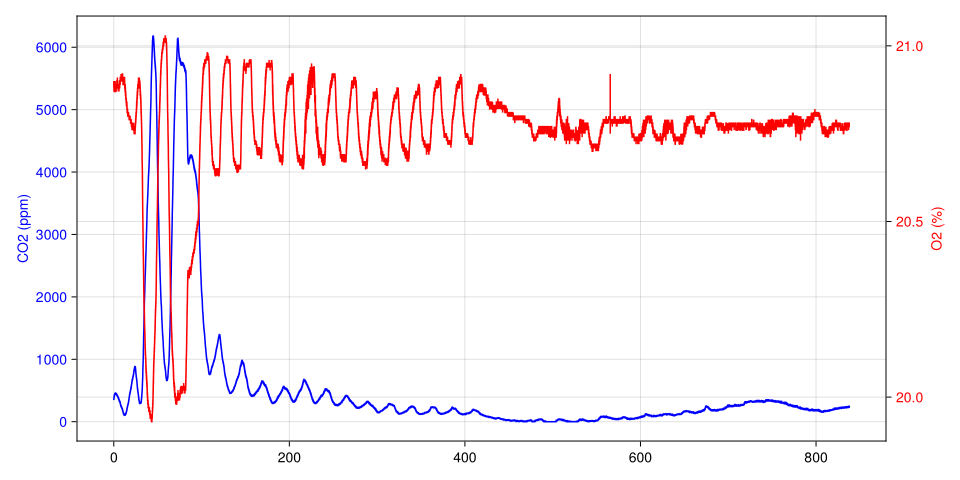

```julia
using CSV, DataFrames, HTTP
using CairoMakie: Figure, Axis, lines!, hidespines!, hidexdecorations!

url = "https://raw.githubusercontent.com/livingphysics/bioreactor_v3/refs/heads/experiments/src/bioreactor_data/20260303_103138/bioreactor_data.csv"
df = CSV.read(HTTP.get(url).body, DataFrame)

fig = Figure()
ax1 = Axis(fig[1,1], ylabel="CO2 (ppm)", yticklabelcolor=:blue, ylabelcolor=:blue)
ax2 = Axis(fig[1,1], ylabel="O2 (%)", yticklabelcolor=:red,
           yaxisposition=:right, ylabelcolor=:red)

hidespines!(ax2)
hidexdecorations!(ax2)  # don't double-draw x ticks

lines!(ax1, df.elapsed_time/3600, df.CO2_ppm, color=:blue, label="CO2")
lines!(ax2, df.elapsed_time/3600, df.O2_percent, color=:red, label="O2")

fig
```

## Glucose Adaptation

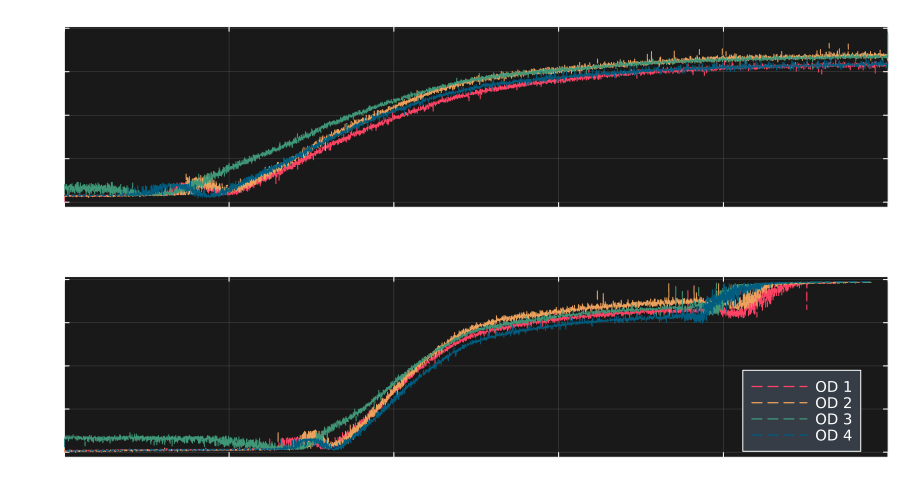

```julia
using CSV, DataFrames, Plots, HTTP

theme(:dark)
default(bg_outside=:transparent, bg_inside="#191919",
        fg_color=:white, fg_color_axis=:white,
        fg_color_border=:white, fg_color_grid=RGBA(1,1,1,0.15),
        fg_color_text=:white, fg_color_guide=:white,
        fg_color_title=:white, fg_color_legend=:white)

url_base = "https://raw.githubusercontent.com/livingphysics/RPi-Biosensor/refs/heads/main/data/"

function make_panel(fname, ttl, show_legend)
    response = HTTP.get(url_base * fname)
    data = CSV.read(response.body, DataFrame)
    t_run = data.elapsed ./ 3600
    OD = [data[:, i+1] for i in 1:4]
    od_max = maximum(maximum.(OD))
    p = plot()
    for i in 1:4
        norm_od = (od_max .- OD[i]) ./ od_max
        plot!(p, t_run, norm_od,
            linestyle=:dash,
            label=show_legend ? "OD $i" : "")
    end
    plot!(p,
        title=ttl, xlabel="time (h)", ylabel="Relative OD",
        xlims=(0, 50),
        guidefontsize=12, titlefontsize=12, legendfontsize=10,
        legend=show_legend ? :bottomright : false,
        framestyle=:box)
    return p
end

gal  = make_panel("250829_naive_galhis_csm-his-leu-gal.csv", "2% Galactose",      false)
glu1 = make_panel("250827_yeast_galhis_csm-his-leu-glu.csv", "2% Glucose Run 1",  true)

display(plot(gal, glu1, layout=(2, 1), size=(900, 500)))
```

## Glucose Adaptation

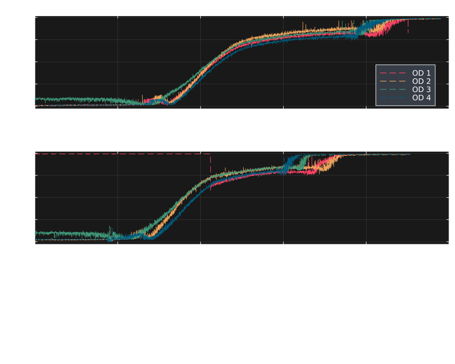

```julia
glu2 = make_panel("250901_naive_galhis_csm-his-leu-glu.csv", "2% Glucose Run 2", false)
display(plot(glu1, glu2, layout=(3, 1), size=(900, 720)))
```

## Glucose Adaptation

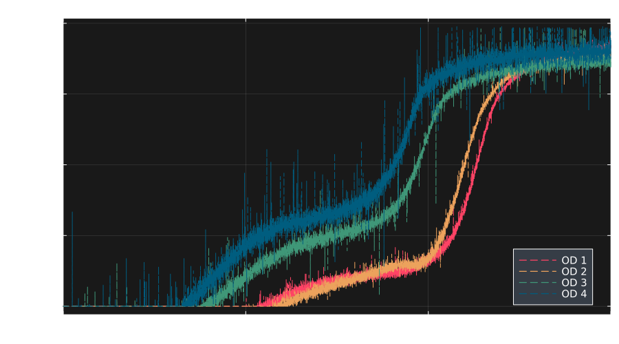

```julia
using CSV, DataFrames, Plots, HTTP

# Dark theme (redundant if previous chunk ran, but makes this chunk self-contained)
theme(:dark)
default(bg_outside=:transparent, bg_inside="#191919",
        fg_color=:white, fg_color_axis=:white,
        fg_color_border=:white, fg_color_grid=RGBA(1,1,1,0.15),
        fg_color_text=:white, fg_color_guide=:white,
        fg_color_title=:white, fg_color_legend=:white)

url_base = "https://raw.githubusercontent.com/livingphysics/Bioreactor_v2/refs/heads/main/bioreactor_data/"
response = HTTP.get(url_base * "20250901_131355_bioreactor_data.csv")
data = CSV.read(response.body, DataFrame)

t_run = data.time ./ 3600
OD = [data[:, i+5] for i in 1:4]
od_max = maximum(maximum.(OD))

p = plot()
for i in 1:4
    norm_od = (od_max .- OD[i]) ./ od_max
    plot!(p, t_run, norm_od,
        linestyle=:dash,
        label="OD $i")
end
plot!(p,
    title="2% Glucose",
    xlabel="time (h)", ylabel="Relative OD",
    xlims=(0, 90),
    guidefontsize=12, titlefontsize=12, legendfontsize=10,
    legend=:bottomright,
    framestyle=:box)

display(plot(p, layout=(1, 1), size=(900, 500), left_margin=8Plots.mm))
```

## Glucose shuts down the promoter

[figure not shown]

Gal (0.5s)

[figure not shown]

Glu post-adaptation (0.5s)

Figure 1: Photomicrographs of rewired cell pre and post adaptation to glucose.

## Colony assays do not support a mutational model

[video not shown]

Time-lapse of 2 colonies growing under a glass coverslip on a +glu-his-leu agar plate

## Improved Colony Assay

[video not shown]

Time-lapse of 2 colonies growing under a glass coverslip on a +glu-his-leu agar plate

## Continuous Culture

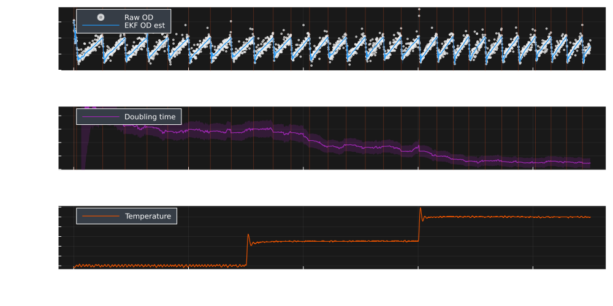

Hoffmann et al. (2017)

## References

Akhlaghpour, Hessameddin. 2022. “An RNA-Based Theory of Natural Universal Computation.” *Journal of Theoretical Biology* 537 (March): 110984. https://doi.org/10.1016/j.jtbi.2021.110984.

Carroll, Sean B. 2013. *Brave Genius: A Scientist, a Philosopher, and Their Daring Adventures from the French Resistance to the Nobel Prize*. Crown. https://www.penguinrandomhouse.com/books/213596/brave-genius-by-sean-b-carroll/.

Costa, Antonio C., Tosif Ahamed, David Jordan, and Greg J. Stephens. 2024. “A Markovian Dynamics for Caenorhabditis elegans Behavior Across Scales.” *Proceedings of the National Academy of Sciences* 121 (32). https://doi.org/10.1073/pnas.2318805121.

Hoffmann, Stefan A, Christian Wohltat, Kristian M Müller, and Katja M Arndt. 2017. “A User-Friendly, Low-Cost Turbidostat with Versatile Growth Rate Estimation Based on an Extended Kalman Filter.” *PLoS One* 12 (7): e0181923.

Jacob, François, and Jacques Monod. 1961. “Genetic Regulatory Mechanisms in the Synthesis of Proteins.” *Journal of Molecular Biology* 3 (3): 318–56. https://doi.org/10.1016/S0022-2836(61)80072-7.

Larson, Ben T., Jack Garbus, Jordan B. Pollack, and Wallace F. Marshall. 2022. “A Unicellular Walker Controlled by a Microtubule-Based Finite-State Machine.” *Current Biology* 32 (17): 3745–3757.e7. https://doi.org/10.1016/j.cub.2022.07.034.

Padmakumar, Jai P., Jessica J. Sun, William Cho, et al. 2024. “Partitioning of a 2-Bit Hash Function Across 66 Communicating Cells.” *Nature Chemical Biology* 21 (2): 268–79. https://doi.org/10.1038/s41589-024-01730-1.

Rogozhin, Yurii. 1996. “Small Universal Turing Machines.” *Theoretical Computer Science* 168 (2): 215–40. https://doi.org/10.1016/S0304-3975(96)00077-1.

Stanton, Brynne C., Alec A. K. Nielsen, Alvin Tamsir, Kevin Clancy, Todd Peterson, and Christopher A. Voigt. 2013. “Genomic Mining of Prokaryotic Repressors for Orthogonal Logic Gates.” *Nature Chemical Biology* 10 (2): 99–105. https://doi.org/10.1038/nchembio.1411.

Stolovicki, Elad, Tali Dror, Naama Brenner, and Erez Braun. 2006. “Synthetic Gene Recruitment Reveals Adaptive Reprogramming of Gene Regulation in Yeast.” *Genetics* 173 (1): 75–85. https://doi.org/10.1534/genetics.106.055442.

Woronoff, Gabrielle, Philippe Nghe, Jean Baudry, et al. 2020. “Metabolic Cost of Rapid Adaptation of Single Yeast Cells.” *Proceedings of the National Academy of Sciences* 117 (20): 10660–66. https://doi.org/10.1073/pnas.1913767117.

Xiang, Yiyu, Neil Dalchau, and Baojun Wang. 2018. “Scaling up Genetic Circuit Design for Cellular Computing: Advances and Prospects.” *Natural Computing* 17 (4): 833–53. https://doi.org/10.1007/s11047-018-9715-9.